# First JAGS models

This short example follows on from this morning’s example where we were exploring how the prior and likelihood combine to generate the posterior. We will now turn to using JAGS as a way to fit the same model. In doing so, it makes it straight forward to estimate multiple parameters simultaneously. We can also use this simple example to understand the process a bit more, and explore important points such as model convergence which becomes more important as the complexity of the models increases: anyone who has used MixSIAR will know this only too well… depending on what you are tyring to do, it is potentially a beast of a model.

## Recreate our simple model

Earlier, we fitted a very simple model where we estimated only the mean of our data, assuming we knew the standard deviation exactly. We can recreate this using JAGS, which is similar in appearance to R code, but it *is not* compatible with R, nor is it ever inpreted by R, and rather it is passed to the underlying JAGS software installed on your computer for evaluation.

The JAGS model is written as plain text, and it is either written to a `*.txt` file and passed to JAGS via the R package `rjags`, or you can write it out in-line in your R code as a string, and pass it as a text object using the function `textConnection()`. We will use the latter approach here as our models are relatively short and it is easier to view them in our R code.

A JAGS model consists of two key components: A section defining the Likelihood, and then a section that defines the Prior distribution for all the unknown parameters that we want to estimate. You dont have to explicitly label these as such, but it is helpful, and it doesnt matter which order you put them in the model code, but again it probably helps to define the likelihood first and the priors second. Beyond simple cases, it sometimes gets confusing as to what is part of the likelihood and what is part of the prior, but that comes with experience.

**N.B.** JAGS uses the precision ($\tau$) notation rather than standard deviation ($\sigma$) or variance ($ ^2$) , so remember that:
$$\sigma^2 = \frac{1}{\tau}$$
and
$$\tau = \frac{1}{\sigma^2} = \sigma^{-2}$$

```r
library(rjags)
# we define our JAGS model as a string of text between two
# inverted commas (either single or double is fine)
modelstring <- '
  model {

    # Define the Likelihood of the data
    # normally distributed with known standard deviation.
    x ~ dnorm(theta, 0.8^-2)

    # Define the Prior for all unknown parameters
    theta ~ dnorm(2.3, 0.5^-2)
  }
'
# Set up data which is passed in to the JAGS model
# as a list, with vectors and matrices the same name
# as appear in the JAGS model.
data <- list(x = 3.1)

# The jags model is initialised using jags.model()
model <- jags.model(textConnection(modelstring), data = data)
```

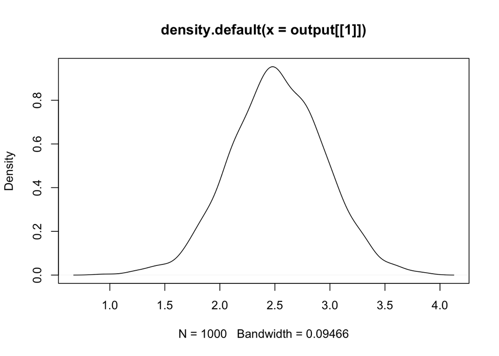

```r
# We then use coda.samples to ask for posterior draws
# which we will use as a reflectin of the posterior.
output <- coda.samples(model = model,
                       variable.names = c("theta"),
                       n.iter = 1000)
# Plot output
plot(density(output[[1]]))
```

And so we get results compatible with our expectation from our earlier excercise, we could confirm by making sure we use exactly the same data and priors.

## Checking model convergence

The iterative process of the MCMC algorithm that underlies JAGS means that we will never get exactly the same posterior distribution if we run the model more than once (except if we set the random number generator seed each time). The algorithm also has to start with an initial guess for the parameters, which if wildly incompatible with the posterior, may take several iterations for it to walk its way to more sensible values. For these reasons, we typically want to run our model more than once, in multiple chains, to assess convergence.

We can run our model again, this time asking for multiple chains: typically three is sufficient. Since we already have our model defined, we can set up the model and samples from it again.

```r
# set up a new model with 3 chains
# The jags model is initialised using jags.model()
model <- jags.model(textConnection(modelstring),
                    data = data,
                    n.chains = 3)
```

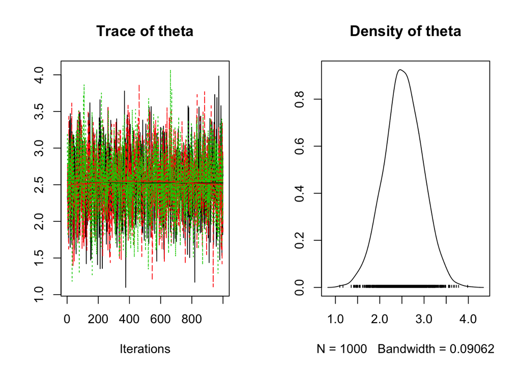

```r
# We then use coda.samples to ask for posterior draws
# which we will use as a reflectin of the posterior.
output <- coda.samples(model = model,
                       variable.names = c("theta"),
                       n.iter = 1000)
# Plot output
# Passing the entire object we called output to plot()
# will automatically create a set of trace and density plots
plot(output)
```

```r
# set up a new model with 3 chains
# The jags model is initialised using jags.model()
model <- jags.model(textConnection(modelstring), data = data,
                    n.chains = 3,
                    inits = list(list(theta = -100),
                                 list(theta = 10),
                                 list(theta = 100)))
```

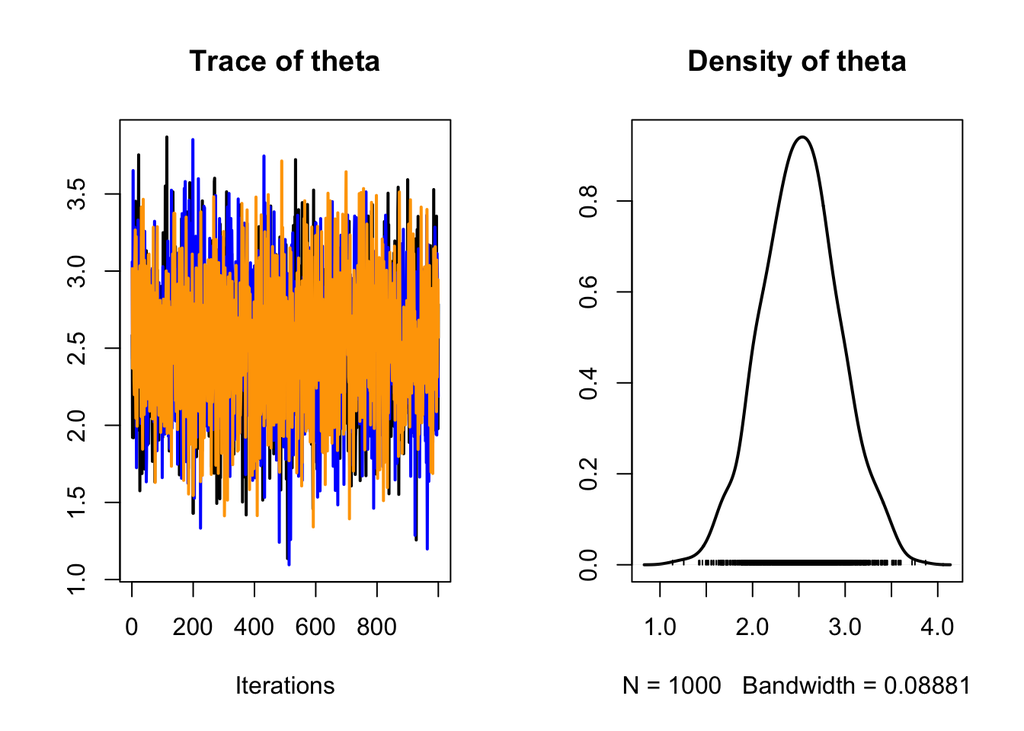

```r
# We then use coda.samples to ask for posterior draws
# which we will use as a reflectin of the posterior.
output <- coda.samples(model = model,
                       variable.names = c("theta"),
                       n.iter = 1000)
# Plot output
# Passing the entire object we called output to plot()
# will automatically create a set of trace and density plots
plot(output, smooth = FALSE, col = c("black", "blue", "orange"), lwd = 2, lty = 1)
```

More information on model checking and convergence diagnostics is available form Andrew Parnell’s script [reg_and_simms](https://cdn.rawgit.com/andrewcparnell/simms_course/9f772e8a/ap_notes/reg_and_simms/reg_and_simms.pdf).